# UNC Salary Analysis

MO SAHOR

02/13/2020

Universities are typically opaque, governmental institutions. To be transparent to tax payers, many public schools, such as the University of North Carolina, openly report **[salary information](http://www.newsobserver.com/news/databases/public-salaries/)**. In this project, we will analyze this information from 2017 to answer pivotal questions that have lived on over the course of time.

To answer all the questions, we will need the R package `tidyverse` to make figures and utilize `dplyr` functions.

```r
library(dplyr)
library(tidyverse)
```

First we load the salary dataset using and name it salary.

```r
salary <- read_csv("UNC_System_Salaries Search and Report.csv", show_col_types = FALSE)
names(salary)
```

```
##  [1] "Name"                  "campus2"               "dept"
##  [4] "position"              "PRIMARY_WORKING_TITLE" "hiredate"
##  [7] "exempt"                "fte"                   "employed"
## [10] "statesal"              "nonstsal"              "totalsal"
## [13] "stservyr"
```

Now, we will explore the information that is contained in this dataset.

```r
names(salary)
```

```
##  [1] "Name"                  "campus2"               "dept"
##  [4] "position"              "PRIMARY_WORKING_TITLE" "hiredate"
##  [7] "exempt"                "fte"                   "employed"
## [10] "statesal"              "nonstsal"              "totalsal"
## [13] "stservyr"
```

Next, lets examine the type of data contained in these different variables.

```r
str(salary, give.attr=F)
```

```
## spec_tbl_df [12,646 × 13] (S3: spec_tbl_df/tbl_df/tbl/data.frame)
##  $ Name                 : chr [1:12646] "AACHOUI, YOUSSEF" "AARNIO, REA T" "ABAJAS, YASMINA L" "ABARBANELL, JEFFERY S" ...
##  $ campus2              : chr [1:12646] "UNC-CHAPEL HILL" "UNC-CHAPEL HILL" "UNC-CHAPEL HILL" "UNC-CHAPEL HILL" ...
##  $ dept                 : chr [1:12646] "Microbiology and Immunology" "SW-Research Projects" "Peds-Hematology/Oncology" "Kenan-Flagler Bus Sch" ...
##  $ position             : chr [1:12646] "Research Professional, Medical" "Functional Paraprofessional" "Assistant Professor" "Associate Professor" ...
##  $ PRIMARY_WORKING_TITLE: chr [1:12646] "Research Associate" "Graphic Designer" "NODESCR" "Associate Professor" ...
##  $ hiredate             : chr [1:12646] "10/10/2011" "1/14/2013" "7/1/2015" "1/1/1999" ...
##  $ exempt               : chr [1:12646] "Exempt from Personnel Act" "Subject to State Personnel Act" "Exempt from Personnel Act" "Exempt from Personnel Act" ...
##  $ fte                  : num [1:12646] 1 0.8 1 1 1 1 1 1 1 1 ...
##  $ employed             : num [1:12646] 12 12 12 9 12 12 12 9 12 9 ...
##  $ statesal             : logi [1:12646] NA NA NA NA NA NA ...
##  $ nonstsal             : logi [1:12646] NA NA NA NA NA NA ...
##  $ totalsal             : num [1:12646] 49128 33257 139405 181000 41098 ...
##  $ stservyr             : num [1:12646] 1 5 2 20 6 8 6 1 19 1 ...
```

Notice that the variable “hiredate” is recorded as a character. I will first modify the original dataset to change this to a date variable with the format *mm/dd/yyyy*. Then, I will remove the hyphens to create a numeric variable as *yyyymmdd*.

```r
salary$hiredate = as.Date(salary$hiredate, format = '%m/%d/%Y')
salary$hiredate = as.numeric(gsub('-','', salary$hiredate))
```

Now lets view the first 5 rows of the modified data.

```r
head(salary, 5)
```

| Name | campus2 | dept | position | PRIMARY_WORKING_TITLE | hiredate | exempt | fte | employed | statesal | nonstsal | totalsal | stservyr |
| --- | --- | --- | --- | --- | --- | --- | --- | --- | --- | --- | --- | --- |
| AACHOUI, YOUSSEF | UNC-CHAPEL HILL | Microbiology and Immunology | Research Professional, Medical | Research Associate | 20111010 | Exempt from Personnel Act | 1.0 | 12 | NA | NA | 49128.00 | 1 |
| AARNIO, REA T | UNC-CHAPEL HILL | SW-Research Projects | Functional Paraprofessional | Graphic Designer | 20130114 | Subject to State Personnel Act | 0.8 | 12 | NA | NA | 33256.66 | 5 |
| ABAJAS, YASMINA L | UNC-CHAPEL HILL | Peds-Hematology/Oncology | Assistant Professor | NODESCR | 20150701 | Exempt from Personnel Act | 1.0 | 12 | NA | NA | 139405.00 | 2 |
| ABARBANELL, JEFFERY S | UNC-CHAPEL HILL | Kenan-Flagler Bus Sch | Associate Professor | Associate Professor | 19990101 | Exempt from Personnel Act | 1.0 | 9 | NA | NA | 181000.00 | 20 |
| ABARE, BETSY | UNC-CHAPEL HILL | Institute of Marine Sciences | Research Asst/Tech, Life Science | Research Technician | 20110912 | Subject to State Personnel Act | 1.0 | 12 | NA | NA | 41098.00 | 6 |

Selecting the features I am interest in.

```r
salary2 = select(salary, 'Name', 'dept', 'position', 'hiredate', 'exempt', 'totalsal')
names(salary2)
```

```
## [1] "Name"     "dept"     "position" "hiredate" "exempt"   "totalsal"
```

Renaming the features

```r
salary3 = rename(salary2, Department=dept, Job=position, Exempt=exempt, Salary=totalsal  )
head(salary3)
```

| Name | Department | Job | hiredate | Exempt | Salary |
| --- | --- | --- | --- | --- | --- |
| AACHOUI, YOUSSEF | Microbiology and Immunology | Research Professional, Medical | 20111010 | Exempt from Personnel Act | 49128.00 |
| AARNIO, REA T | SW-Research Projects | Functional Paraprofessional | 20130114 | Subject to State Personnel Act | 33256.66 |
| ABAJAS, YASMINA L | Peds-Hematology/Oncology | Assistant Professor | 20150701 | Exempt from Personnel Act | 139405.00 |
| ABARBANELL, JEFFERY S | Kenan-Flagler Bus Sch | Associate Professor | 19990101 | Exempt from Personnel Act | 181000.00 |
| ABARE, BETSY | Institute of Marine Sciences | Research Asst/Tech, Life Science | 20110912 | Subject to State Personnel Act | 41098.00 |
| ABATE, AARON B | Med Ad-Fin and Bus Operations | Fiscal Affairs Paraprofessional | 20090420 | Subject to State Personnel Act | 55812.00 |

Creating a new variable called HireYear from the hiredate column that only contains the year of the date

```r
salary4 = mutate(salary3, HireYear = floor(hiredate/10000))
str(salary4)
```

```
## tibble [12,646 × 7] (S3: tbl_df/tbl/data.frame)
##  $ Name      : chr [1:12646] "AACHOUI, YOUSSEF" "AARNIO, REA T" "ABAJAS, YASMINA L" "ABARBANELL, JEFFERY S" ...
##  $ Department: chr [1:12646] "Microbiology and Immunology" "SW-Research Projects" "Peds-Hematology/Oncology" "Kenan-Flagler Bus Sch" ...
##  $ Job       : chr [1:12646] "Research Professional, Medical" "Functional Paraprofessional" "Assistant Professor" "Associate Professor" ...
##  $ hiredate  : num [1:12646] 20111010 20130114 20150701 19990101 20110912 ...
##  $ Exempt    : chr [1:12646] "Exempt from Personnel Act" "Subject to State Personnel Act" "Exempt from Personnel Act" "Exempt from Personnel Act" ...
##  $ Salary    : num [1:12646] 49128 33257 139405 181000 41098 ...
##  $ HireYear  : num [1:12646] 2011 2013 2015 1999 2011 ...
```

Creating another variable from HireYear called YrsEmployed that contains the number of years a staff has been emloyed.

```r
salary5 = mutate(salary4, YrsEmployed = 2017 - HireYear)
str(salary5)
```

```
## tibble [12,646 × 8] (S3: tbl_df/tbl/data.frame)
##  $ Name       : chr [1:12646] "AACHOUI, YOUSSEF" "AARNIO, REA T" "ABAJAS, YASMINA L" "ABARBANELL, JEFFERY S" ...
##  $ Department : chr [1:12646] "Microbiology and Immunology" "SW-Research Projects" "Peds-Hematology/Oncology" "Kenan-Flagler Bus Sch" ...
##  $ Job        : chr [1:12646] "Research Professional, Medical" "Functional Paraprofessional" "Assistant Professor" "Associate Professor" ...
##  $ hiredate   : num [1:12646] 20111010 20130114 20150701 19990101 20110912 ...
##  $ Exempt     : chr [1:12646] "Exempt from Personnel Act" "Subject to State Personnel Act" "Exempt from Personnel Act" "Exempt from Personnel Act" ...
##  $ Salary     : num [1:12646] 49128 33257 139405 181000 41098 ...
##  $ HireYear   : num [1:12646] 2011 2013 2015 1999 2011 ...
##  $ YrsEmployed: num [1:12646] 6 4 2 18 6 8 5 1 12 1 ...
```

Sorting the data by Years Employed.

```r
salary5%>%
  arrange(YrsEmployed)%>%
  head(10)
```

| Name | Department | Job | hiredate | Exempt | Salary | HireYear | YrsEmployed |
| --- | --- | --- | --- | --- | --- | --- | --- |
| ABERNETHY, TAYLOR G | Sch of Inform and Libr Science | Librarian AD, Head of Technical Services | 20170201 | Exempt from Personnel Act | 51000 | 2017 | 0 |
| ADAMS, BLAIR J | LCCC - Clinical Trials | Research Asst/Tech, Social Science | 20170227 | Subject to State Personnel Act | 55652 | 2017 | 0 |
| ADAMS, DEMETRIUS D | Ath Football Office | Assistant Coach - Football | 20170122 | Exempt from Personnel Act | 300000 | 2017 | 0 |
| ADAMS, JEANINE G | Ath Olympic Sport Administratn | Administrative / Office / Clerical Support Staff, Other | 20170717 | Subject to State Personnel Act | 19276 | 2017 | 0 |
| ADAMS, JORDAN D | ITS - Teaching and Learning | IT Client Support Professional, Specialist | 20170103 | Subject to State Personnel Act | 51000 | 2017 | 0 |
| AGNER, JOSHUA L | SOG Sch of Government | Accounting Professional | 20170828 | Subject to State Personnel Act | 57000 | 2017 | 0 |
| AHMED, RIAZ | ITS - User Supp and Engagement | IT (Information Technology) Professional, IT Architect | 20170821 | Subject to State Personnel Act | 95000 | 2017 | 0 |
| AKERMAN, ADAM W | Surgery - Cardiothoracic | Research Professional, Medical | 20170701 | Exempt from Personnel Act | 90000 | 2017 | 0 |
| AKRIDGE, MICHAEL C | Lineberger Compr Cancer Center | Administrative / Office / Clerical Support Staff, Other | 20170410 | Subject to State Personnel Act | 40000 | 2017 | 0 |
| ALEXANDER, DARREN L | Computer Science | Administrative Assistant | 20170703 | Subject to State Personnel Act | 49719 | 2017 | 0 |

Dropping hiredate and HireYear columns and sorting the data by years employed and department, then making years employed and salary columns first 2 columns in the dataset.

```r
salary.final = salary5 %>%
  select(-hiredate, -HireYear) %>%
  arrange(YrsEmployed, Department) %>%
  select(YrsEmployed, Salary, everything())
head(salary.final, 10)
```

| YrsEmployed | Salary | Name | Department | Job | Exempt |
| --- | --- | --- | --- | --- | --- |
| 0 | 39646 | DALEY, JOSEPH J | A and S - Business Center | Fiscal Affairs Paraprofessional | Subject to State Personnel Act |
| 0 | 48814 | WEBSTER, CAITLIN M | A and S - Business Center | HR Coordinator | Subject to State Personnel Act |
| 0 | 48814 | WOODSON, KIMBERLY S | A and S - Business Center | HR Coordinator | Subject to State Personnel Act |
| 0 | 48814 | WORTHEN, TIFFANY M | A and S - Business Center | HR Coordinator | Subject to State Personnel Act |
| 0 | 47476 | JONES, CLIFFORD R | Academic Advising | Academic Advising Professional | Exempt from Personnel Act |
| 0 | 58000 | MITCHALL, ALLISON M | Academic Advising | Academic Advising Professional | Exempt from Personnel Act |
| 0 | 47476 | RICHARDS, KRISTIN E | Academic Advising | Academic Advising Professional | Exempt from Personnel Act |
| 0 | 47476 | VIRAY, JEAN-PAUL | Academic Advising | Academic Advising Professional, Advisor/Coordinator | Exempt from Personnel Act |
| 0 | 60000 | WALDIE, ALEXANDER L | Academic Advising | Academic Advising Professional | Exempt from Personnel Act |
| 0 | 65000 | ALLEN, DAYSI G | Accounting Services | Accounting Professional | Subject to State Personnel Act |

Seeing if there are any null values.

```r
anyNA(salary.final)
```

```
## [1] FALSE
```

Adding a variable called lessthan6 that returns true if salary is less than six figures and false if more than six figures.

```r
sixfig_jobs = mutate(salary.final, lessthan6 = Salary <= 100000 )
head(sixfig_jobs)
```

| YrsEmployed | Salary | Name | Department | Job | Exempt | lessthan6 |
| --- | --- | --- | --- | --- | --- | --- |
| 0 | 39646 | DALEY, JOSEPH J | A and S - Business Center | Fiscal Affairs Paraprofessional | Subject to State Personnel Act | TRUE |
| 0 | 48814 | WEBSTER, CAITLIN M | A and S - Business Center | HR Coordinator | Subject to State Personnel Act | TRUE |
| 0 | 48814 | WOODSON, KIMBERLY S | A and S - Business Center | HR Coordinator | Subject to State Personnel Act | TRUE |
| 0 | 48814 | WORTHEN, TIFFANY M | A and S - Business Center | HR Coordinator | Subject to State Personnel Act | TRUE |
| 0 | 47476 | JONES, CLIFFORD R | Academic Advising | Academic Advising Professional | Exempt from Personnel Act | TRUE |
| 0 | 58000 | MITCHALL, ALLISON M | Academic Advising | Academic Advising Professional | Exempt from Personnel Act | TRUE |

How many employees earn more than six figure at UNC and how many do not? From those that earn six figures and don’t, how many are under the State Personnel Act?

The State Personnel Act is meant to cover employees whose primary job responsibilities are in emergency management coordination. There salary is funded, in whole or in part, by federal homeland security or emergency management funds.

Plotting graph to visualize answer.

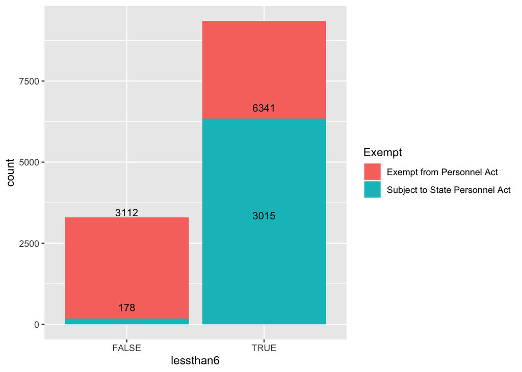

```r
ggplot(sixfig_jobs, aes(x = lessthan6)) +
  geom_bar(aes(fill = Exempt)) +
  geom_text(aes(label=..count..,group=Exempt), stat='count', vjust=-1, hjust =0.5, color="black",size=3.5)
```

Lets now look at some departments at UNC and answer some questions based on them.

What is the average salary of employees in the Computer Science Department?

```r
compsal = salary.final %>%
  filter(Department == 'Computer Science') %>%
  select(Salary) %>%
  sapply(mean)

 cat('Average Computer Science Department Salary is ', compsal,'k')
```

```
## Average Computer Science Department Salary is  108320.9 k
```

How many employees have worked in Psychology and Neuroscience between 4 and 7 years (inclusive) and are exempt from personnel act?

```r
n = salary.final %>%
  filter(Department == 'Psychology and Neuroscience') %>%
  filter(YrsEmployed >= 4 & YrsEmployed <= 7) %>%
  filter(Exempt == 'Exempt from Personnel Act') %>%
  nrow()

cat(n, 'Employees')
```

```
## 9 Employees
```

What is the mean salary of employees from the Biology department who are professors, associate professors, or assistant professors?

```r
m = salary.final %>%
  filter(Department == 'Biology') %>%
  filter(Job == 'Professor' |
           Job == 'Associate Professor' |
           Job == "Assistant Professor") %>%
  select(Salary) %>%
  sapply(mean)

cat('Mean salary of employees from the Biology department who are professors, associate professors, or assistant professors is', m,'k')
```

```
## Mean salary of employees from the Biology department who are professors, associate professors, or assistant professors is 115256.8 k
```

Creating a grouped summary based off combinations of “Department” and “YrsEmployed”. The summary will report all of the following statistics: - number of employees for each combination - average salary for each combination - standard deviation of salary for each combination - minimum salary for each combination - maximum salary for each combination

```r
deptyear_summary = salary.final %>%
  group_by(Department, YrsEmployed) %>%
  summarise('numOfEmployees' = n(),
            'avgSalary' = mean(Salary),
            'stdSalary' = sd(Salary),
            'minSalary' = min(Salary),
            'maxSalary' = max(Salary))

deptyear_summary %>% ungroup() %>% head(10)
```

| Department | YrsEmployed | numOfEmployees | avgSalary | stdSalary | minSalary | maxSalary |
| --- | --- | --- | --- | --- | --- | --- |
| A and S - Business Center | 0 | 4 | 46522.00 | 4584.0000 | 39646 | 48814 |
| A and S - Business Center | 1 | 4 | 43609.75 | 4589.1407 | 39646 | 47983 |
| A and S - Business Center | 2 | 2 | 48398.50 | 587.6057 | 47983 | 48814 |
| A and S - Business Center | 3 | 2 | 52189.50 | 2703.2692 | 50278 | 54101 |
| A and S - Business Center | 4 | 2 | 54488.00 | 9199.4592 | 47983 | 60993 |
| Acad Initiatives-UBC | 1 | 1 | 23250.00 | NA | 23250 | 23250 |
| Acad Initiatives-UBC | 3 | 1 | 48782.00 | NA | 48782 | 48782 |
| Acad Initiatives-UBC | 6 | 1 | 60341.00 | NA | 60341 | 60341 |
| Acad Initiatives-UBC | 7 | 1 | 54851.00 | NA | 54851 | 54851 |
| Acad Initiatives-UBC | 14 | 2 | 64916.00 | 12875.0003 | 55812 | 74020 |

Testing if the summary is accurate.

```r
salary.final %>%
  filter(Department == 'A and S - Business Center' & YrsEmployed == 0)
```

| YrsEmployed | Salary | Name | Department | Job | Exempt |
| --- | --- | --- | --- | --- | --- |
| 0 | 39646 | DALEY, JOSEPH J | A and S - Business Center | Fiscal Affairs Paraprofessional | Subject to State Personnel Act |
| 0 | 48814 | WEBSTER, CAITLIN M | A and S - Business Center | HR Coordinator | Subject to State Personnel Act |
| 0 | 48814 | WOODSON, KIMBERLY S | A and S - Business Center | HR Coordinator | Subject to State Personnel Act |
| 0 | 48814 | WORTHEN, TIFFANY M | A and S - Business Center | HR Coordinator | Subject to State Personnel Act |

We can see that the summary is accurate because there are 4 employees in ‘A and S - Business Center’ Department with YrsEmployed = 0.

```r
deptyear_summary %>%
  arrange(-avgSalary) %>%
  filter(YrsEmployed == 3) %>%
  head(5)
```

| Department | YrsEmployed | numOfEmployees | avgSalary | stdSalary | minSalary | maxSalary |
| --- | --- | --- | --- | --- | --- | --- |
| Neurosurgery - Offsite | 3 | 1 | 599961.8 | NA | 599961.8 | 599961.8 |
| Surgery - Cardiothoracic | 3 | 1 | 468000.0 | NA | 468000.0 | 468000.0 |
| WSEE-Ofc of Vice Chancellor | 3 | 1 | 376518.8 | NA | 376518.8 | 376518.8 |
| ENT - Otology | 3 | 1 | 335997.0 | NA | 335997.0 | 335997.0 |
| Medicine-Gastroenterology | 3 | 2 | 333542.5 | 164837.2 | 216985.0 | 450100.0 |

List 5 departments has the highest number of employees who have been employed for 10.

```r
deptyear_summary %>%
  arrange(-numOfEmployees) %>%
  filter(YrsEmployed == 10) %>%
  head(5)
```

| Department | YrsEmployed | numOfEmployees | avgSalary | stdSalary | minSalary | maxSalary |
| --- | --- | --- | --- | --- | --- | --- |
| Kenan-Flagler Bus Sch | 10 | 16 | 125312.67 | 76756.84 | 45152.50 | 267113.0 |
| Sch of Nursing | 10 | 14 | 89993.07 | 29355.12 | 49015.37 | 160708.7 |
| University Library | 10 | 11 | 61251.81 | 16967.46 | 38669.00 | 87275.0 |
| Romance Studies | 10 | 9 | 53404.33 | 18413.26 | 41905.00 | 87899.0 |
| Comparative Medicine | 10 | 8 | 57029.36 | 18943.94 | 38068.82 | 84737.5 |

What is the relationship between average salary and the years employeed?

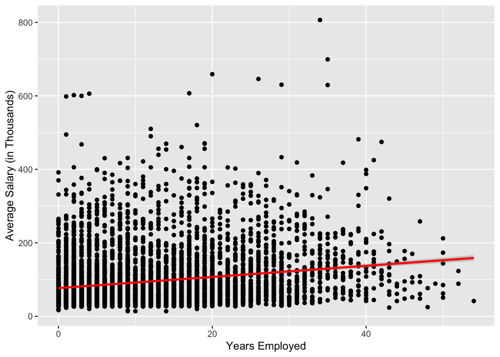

```r
ggplot(deptyear_summary, aes(x = YrsEmployed, y = avgSalary/1000 )) +
  geom_point() +
  geom_smooth(method = 'lm', color = 'red') +
  xlab('Years Employed') +
  ylab('Average Salary (in Thousands)')
```

There is a weak positive linear relationship between Average Salary and Years of Experience meaning the longer you are employed, the higher your earn but some exceptions occur where less employment years get paid higher salary.

Total number of departments. For the sake of space, I am not going to list them all.

```r
length(unique(deptyear_summary$Department))
```

```
## [1] 702
```

Let’s see the relationship between years employed and average salary for my top 4 favorite departments.

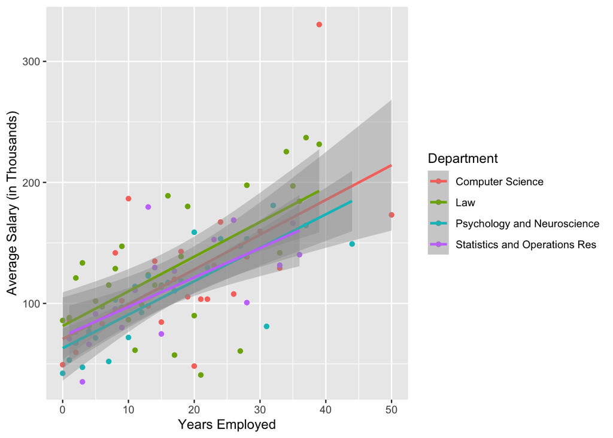

```r
temp = deptyear_summary %>% filter(Department == "Computer Science" | Department == "Psychology and Neuroscience" | Department == "Statistics and Operations Res" | Department == "Law")

ggplot(temp, aes(x = YrsEmployed, y = avgSalary/1000, color = Department)) + geom_point() + geom_smooth(method = 'lm') + xlab('Years Employed') +ylab('Average Salary (in Thousands)')
```

Which department has the highest starting salary? Describe their rate of increase in salary.

Law department has the highest starting salary, that can be due to employees in Law department having higher level of education before they start working. All the departments have a positive linear relationship between years employed and average salary meaning they all get higher salary the more time they stay employed.